# HW5-lil112

Liping Li (lil112@pitt.edu)

2017.03.28

# Task 1: aanalyze the topical clusters from text data

### Load data

```r
data.file = "http://www.yurulin.com/class/spring2017_datamining/data/Newsgroup.csv"
NewsGroup = read.csv("Newsgroup.csv")
NewsGroup[1:3,]
```

```
##         Topic
## 1 alt.atheism
## 2 alt.atheism
## 3 alt.atheism
##                                                                                                                                                                                                                                                                                                          …
## 1 amus atheist and agnost articl timmbak mcl timmbak mcl ucsb edu clam bake timmon write fallaci atheism faith hear faq beckon onc wonder rule delet you correct you didn conspiraci correct hard atheism faith rule don mix appl orang can you that extermin mongol wors stalin khan conquer peopl unsym…
## 2                                                                                                                                                                                                                                                                                                        …
## 3                                                                                                                                                                                                                                                                                                        …
```

## 1.1 Popular Topics

Plot the histogram of number of documents per topic. Find and list the four most popular topics in terms of number of documents.

### Histogram of Topic frequency

```r
library(ggplot2)
theme_bw()
```

[output not shown]

[output cut: 342 more lines]

[output not shown]

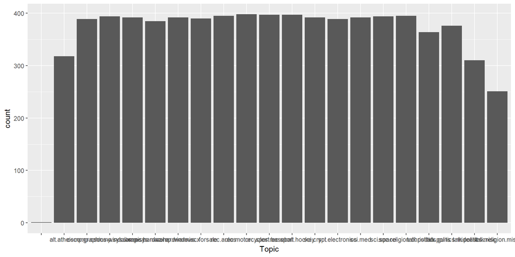

```r
ggplot(NewsGroup, aes(x=Topic)) + geom_histogram(stat = "count")
```

Most topics have more than 250 documents. And 1 topic without name has less than 10 documents.

### 4 popular topics

```r
toptable = as.data.frame(table(NewsGroup$Topic))
toptable = toptable[order(toptable$Freq, decreasing = T),]
toptable[1:4,]
```

```
##                  Var1 Freq
## 10    rec.motorcycles  398
## 11 rec.sport.baseball  397
## 12   rec.sport.hockey  397
## 9           rec.autos  395
```

Totally 21 topics. **rec.motorcycles, rec.sport.baseball, rec.sport.hockey, and rec.auto** are most popular 4 topics.

## 1.2 MDS of 4 popular content

Extract contents in these top 4 topics as your corpus. Run pre-processing on this corpus and use terms that appear at least four times in the corpus to create a term-document matrix. Use the term-document matrix to generate an MDS plot where each node represents a document with color indicating its topic.

### Extract documents of 4 popular topics

```r
select.topics = as.vector(toptable[1:4,1])

library(plyr)
doc.idx = which(NewsGroup$Topic %in% select.topics)
dataset = NewsGroup[doc.idx, ]

library(tm)
## create a corpus
corpus = Corpus(VectorSource(dataset$Content))
corpus
```

```
## <<SimpleCorpus>>
## Metadata:  corpus specific: 1, document level (indexed): 0
## Content:  documents: 1587
```

### Preprocess Corpus

```r
corpus = tm_map(corpus, tolower)
corpus = tm_map(corpus, removePunctuation)
corpus = tm_map(corpus, removeNumbers)
corpus = tm_map(corpus, function(x) removeWords(x, stopwords("english")))
corpus = tm_map(corpus, stemDocument, language = "english")
corpus = tm_map(corpus, stripWhitespace)
inspect(corpus[1:3])
```

```
## <<SimpleCorpus>>
## Metadata:  corpus specific: 1, document level (indexed): 0
## Content:  documents: 3
##
## [1] auto air condit freon articl hvx new cso uiuc edu tspila uxa cso uiuc edu tim spila romulan write articl apr ntuix ntu mgqlu ntuix ntu max write work ga solid adsorpt air con system auto applic thi kind system energi regen adsorb exhaust ga interest thi mail email follow thi thread discuss pr…
## [2] auto air condit freon rovax tobia convex allen tobia write year ago demonstr cold air system us air call rovax unit work short come seal technolog todai recal read post back rovax rovac di larger noisier compet cheap system dai case bad time system chanc todai system death row investor hard c…
## [3] auto air condit freon simpl principl porou adsorb zeolit activ carbon can adsorb gase evapor adsorb water methanol etc give cool effect heat ga satur adsorb bed will give gase conden thi form adsorpt refrig cycl problem cop low max max phd internet mgqlu ntu divi thermal engin bitnet mgqlu nt…
```

```r
#corpus = tm_map(corpus, PlainTextDocument)
td.mat = TermDocumentMatrix(corpus)
dim(td.mat)
```

```
## [1] 13547  1587
```

Rows are terms, and columns are documents.

### Term frequency >= 4

```r
term.idx=c(findFreqTerms(td.mat, lowfreq=4))
td.mat = td.mat[term.idx, ]
dim(td.mat)
```

```
## [1] 5313 1587
```

### MDS plot based on TermDocumentMatrix

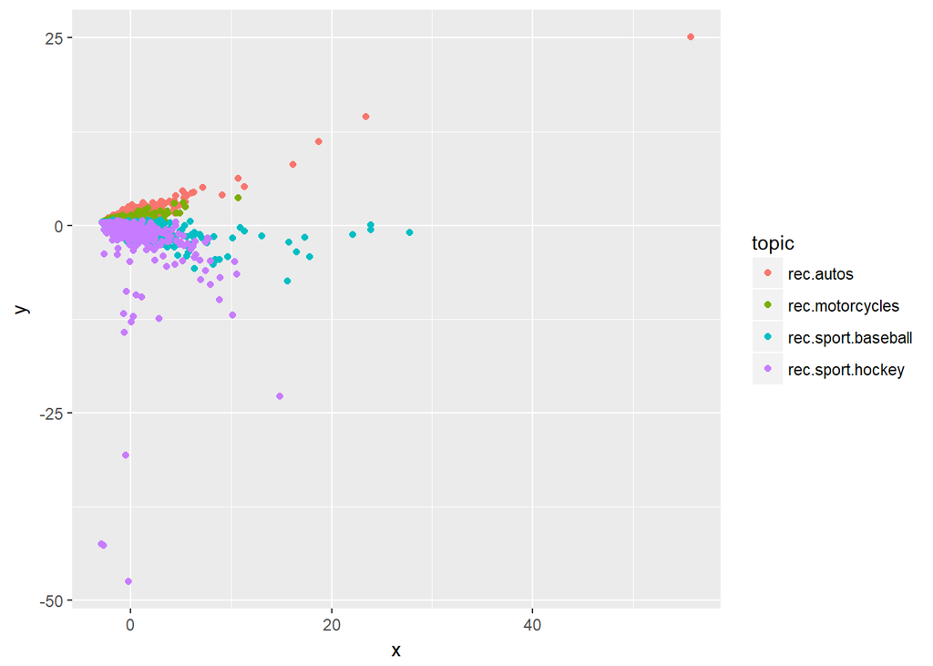

```r
mdsplot <- function(td.mat)
{
dist.mat = dist(t(as.matrix(td.mat)))  ## compute distance matrix

doc.mds = cmdscale(dist.mat, k = 2)
data = data.frame(x = doc.mds[, 1], y = doc.mds[, 2], topic = dataset$Topic, id = row.names(dataset))
library(ggplot2)
ggplot(data, aes(x = x, y = y, color = topic)) + geom_point()
}
mdsplot(td.mat)
```

These topics do not have a good separation from each other. Maybe they’re all from recreation or sports group.

## 1.3 MDS based on different matrix

Apply TFIDF weighting, latent semantic analysis (LSA) and non-negative matrix factorization (NMF) on the term-document matrix. Generate MDS plots corresponding to these matrices (TFIDF weighted matrix, LSA approximated matrix, and NMF approximated matrix).

### MDS plot based on TFIDF

```r
library(lsa)
```

```
## Note: no visible binding for global variable 'ggplot2'
## Note: no visible binding for global variable 'x'
## Note: no visible binding for global variable 'y'
## Note: no visible binding for global variable 'topic'
```

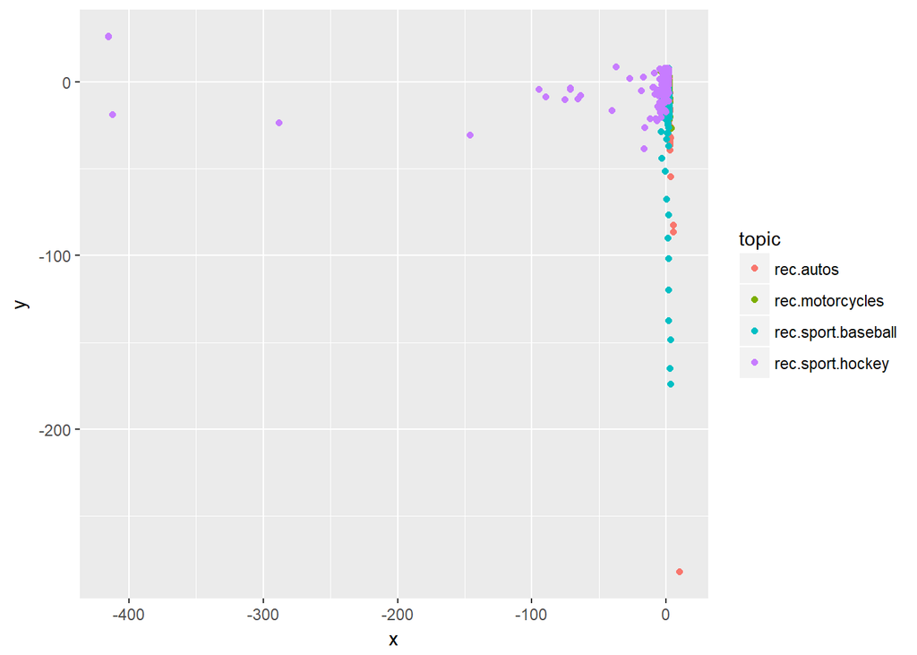

[output not shown]

```r
td.mat = as.matrix(td.mat)
td.mat.w <- lw_tf(td.mat) * gw_idf(td.mat)  ## tf-idf weighting
mdsplot(td.mat.w)
```

### MDS plot based on LSA

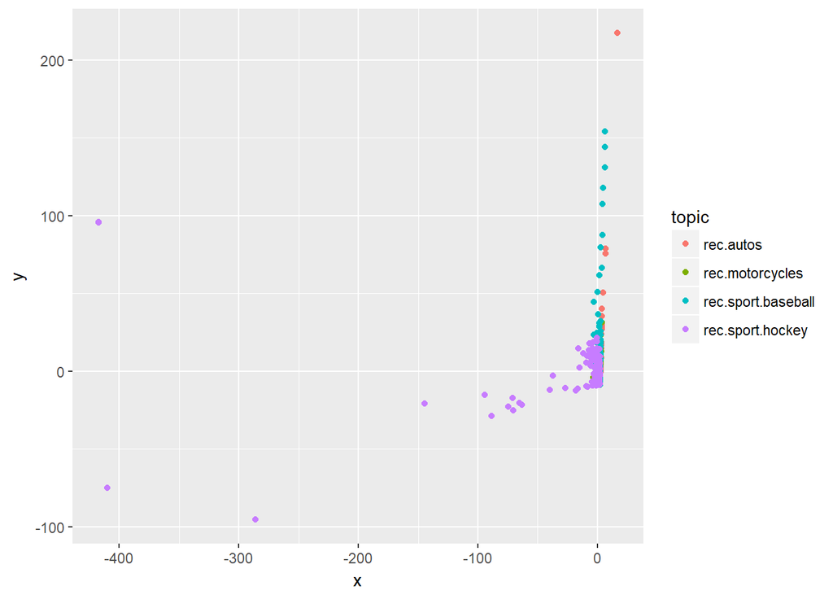

```r
lsa.space = lsa(td.mat.w,dims=4)  ## create LSA space, 4 topics
lsa.mat = as.textmatrix(lsa.space)
mdsplot(lsa.mat)
```

### MDS plot based on NMF

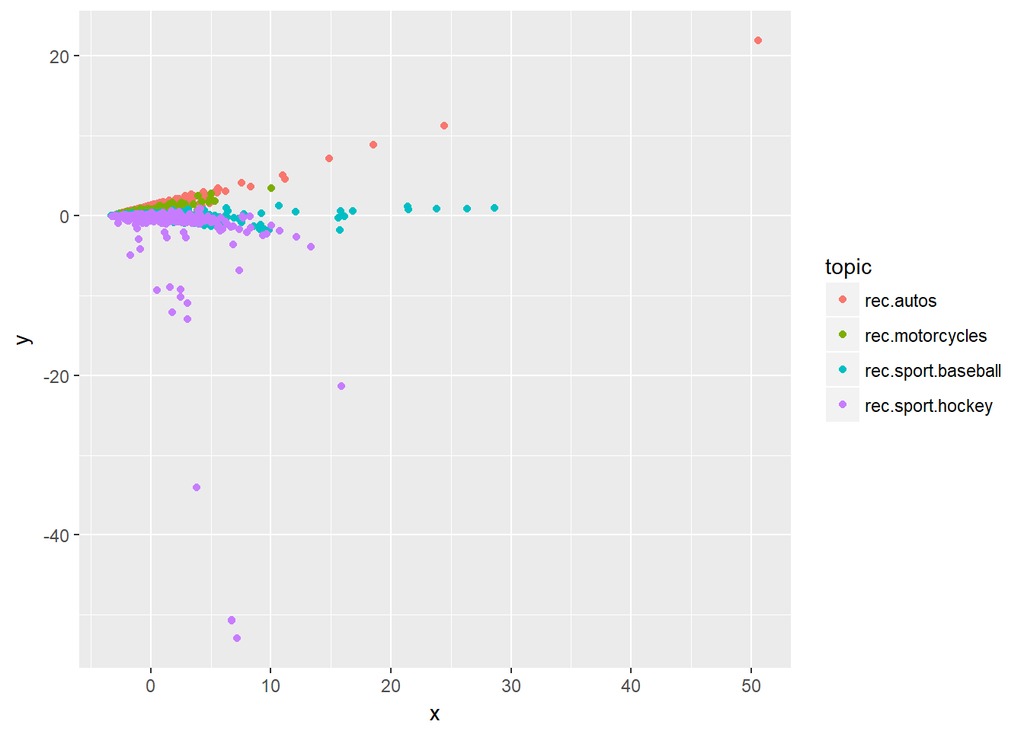

```r
suppressMessages(library(NMF))
set.seed(12345)
res = nmf(td.mat, 4,"lee") # lee & seung method, 4 topics
V.hat = fitted(res) # target matrix
mdsplot(V.hat)
```

Try with Topic x Document matrix.

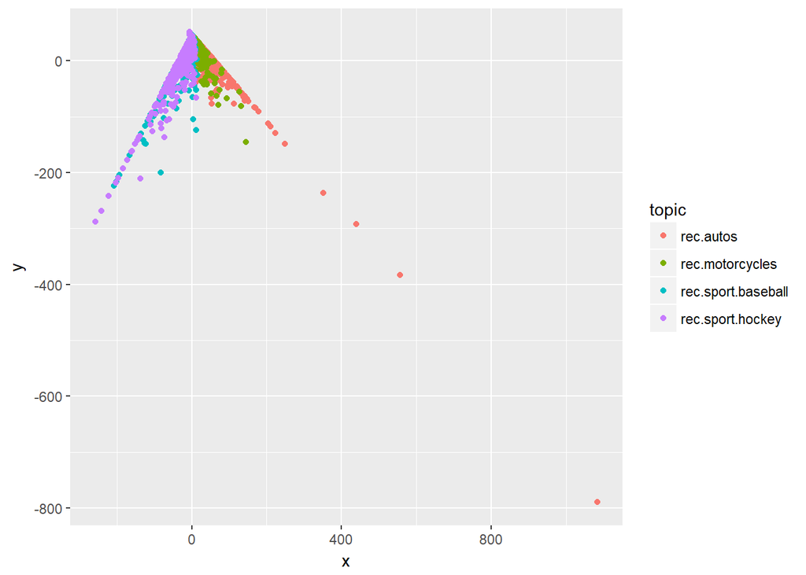

```r
h = coef(res)
h = as.matrix(h)
mdsplot(h)
```

## 1.4 Observation Summary

All these topic groups coverge at (0,0) and have a big overlap. Maybe because they are all associate with recreation or sports.

```r
rm(list = ls())
```

# Task 2: Create a movie-to-movie co-rating network

## 2.1 Prepare data

Extract data where the ratings are generated after timestamp 03/20/1998 00:00:00 and equal to rating 5. Extract the top 30 most frequently rated movies as the nodes.

```r
data.file = "http://files.grouplens.org/datasets/movielens/ml-100k/u.data"
dataset = read.csv(data.file, sep = "\t", header = F)
colnames(dataset) = c("userID","itemID", "rating", "timestamp")
dim(dataset)
```

```
## [1] 100000      4
```

03/20/1998 00:00:00 converts to unix time is 890352000. Rating equals 5.

```r
d1 = subset(dataset, timestamp > 890352000)
d1 = subset(d1, rating == 5)

# Extract the top 30 most frequently rated movies' ID
movies = sort(table(d1$itemID), decreasing = T)
movies = rownames(movies[1:30])
movies[1:4]
```

```
## [1] "50"  "313" "272" "100"
```

Generate a network with edge weights >= 10, i.e., two movies have a link if they are rated by at least 10 common users.

```r
library(igraph)
d1 = subset(d1, itemID %in% movies)
g = graph.data.frame(d1, directed = T)
mat = as.matrix(get.adjacency(g))
m1 = t(mat) %*% mat # movie-movie matrix
m1[m1 < 10] = 0 # number of ratings < 10, then 0

movie.idx = which(colSums(m1) >= 10)
movie.mat = m1[movie.idx, movie.idx]
diag(movie.mat) = 0 # self with self = 0, contained in movie.mat

movie.idx = which(colSums(movie.mat) >= 10)
# self with self = 0, not contained in movie.mat2
movie.mat2 = movie.mat[movie.idx, movie.idx]

dim(movie.mat)
```

```
## [1] 30 30
```

```r
dim(movie.mat2)
```

```
## [1] 26 26
```

Load u.item to replace movieID with movies titles. List the names of the top 10 movies and their number of ratings.

```r
title.idx = as.numeric(rownames(movie.mat))
titles.path = "http://files.grouplens.org/datasets/movielens/ml-100k/u.item"
movie.titles = read.csv(titles.path, sep="|", fill=T, header=F)
movie.names = movie.titles[title.idx,1:2]
row.names(movie.mat)=movie.names$V2 # replace rownames of movie.mat
colnames(movie.mat)=movie.names$V2

title.idx2 = as.numeric(rownames(movie.mat2))
movie.names2 = movie.titles[title.idx2,1:2]
row.names(movie.mat2)=movie.names2$V2 # replace rownames of movie.mat
colnames(movie.mat2)=movie.names2$V2

# get number of ratings
numRatings = data.frame(rowSums(movie.mat))
numRatings = cbind(data.frame(movie.names$V2),numRatings)
colnames(numRatings) = c("title","numRatings")
row.names(numRatings)= NULL
numRatings = numRatings[order(numRatings$numRatings, decreasing = T),]
numRatings[1:10,]
```

```
##                                     title numRatings
## 28                       Star Wars (1977)        287
## 10                  Godfather, The (1972)        149
## 29                Schindler's List (1993)        146
## 20 One Flew Over the Cuckoo's Nest (1975)        145
## 6                      Rear Window (1954)        134
## 9          Raiders of the Lost Ark (1981)        122
## 1                     Pulp Fiction (1994)        121
## 7        Silence of the Lambs, The (1991)        110
## 23           It's a Wonderful Life (1946)         99
## 30           To Kill a Mockingbird (1962)         98
```

## 2.2 Identify the community

Identify the community structure in the network by using the modularity-based community detection algorithm.

### movie.mat 30x30

```r
g1 = graph.adjacency(movie.mat, weighted=T, mode = "undirected", diag = F)
## get modularity-based community
fc = fastgreedy.community(g1)
modularity(fc)
```

```
## [1] 0.2449576
```

Plot the network with the detected community structure and the dendrogram .

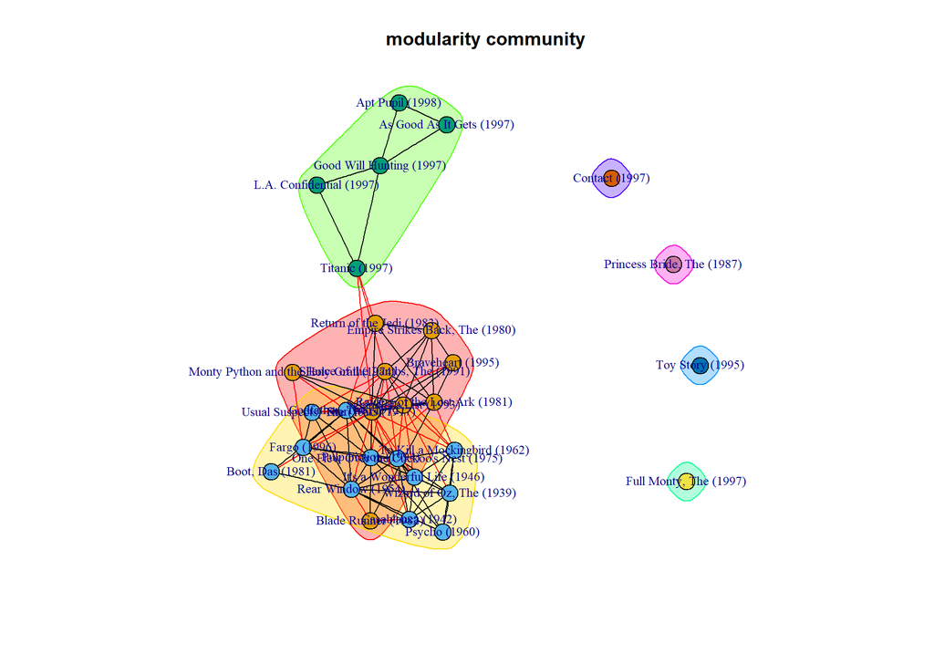

```r
set.seed(1)
plot(fc, g1, main = "modularity community", layout = layout.fruchterman.reingold,
     vertex.size = 8, vertex.label.cex = 0.8)
```

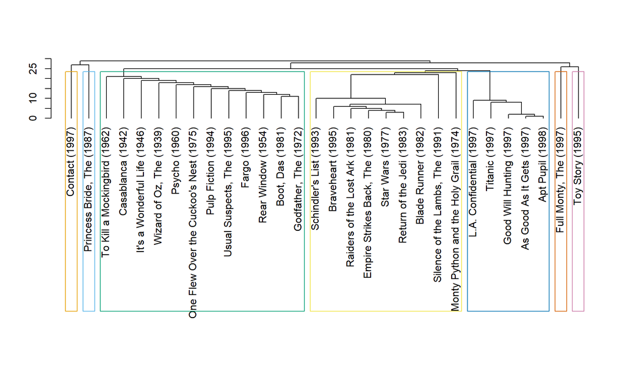

```r
dendPlot(fc)
```

### movie.mat2 26x26

```r
g2 = graph.adjacency(movie.mat2, weighted=T, mode = "undirected", diag = F)
## get modularity-based community
fc = fastgreedy.community(g2)
modularity(fc)
```

```
## [1] 0.2449576
```

Plot the network with the detected community structure and the dendrogram .

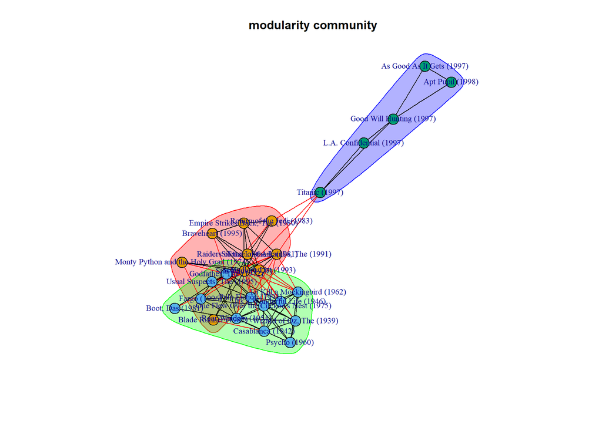

```r
set.seed(1)
plot(fc, g2, main = "modularity community", layout = layout.fruchterman.reingold,
     vertex.size = 8, vertex.label.cex = 0.8)
```

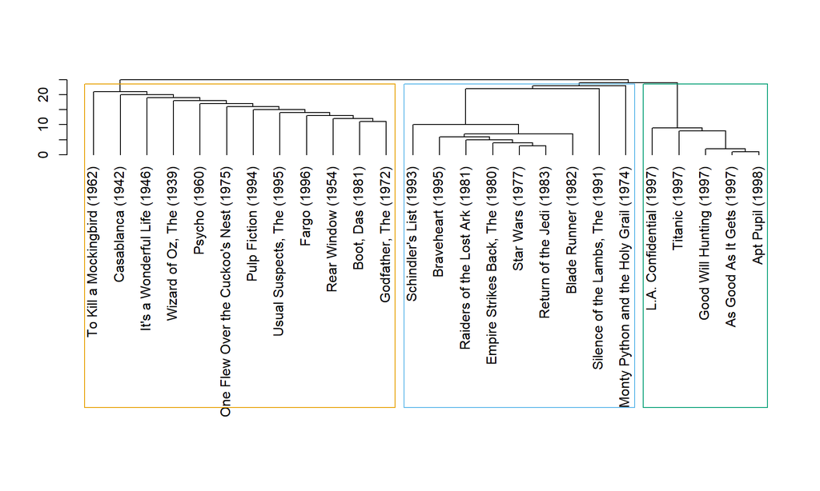

```r
dendPlot(fc)
```

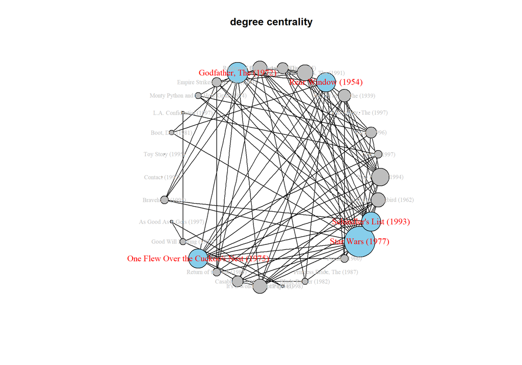

```r
deg = degree(g1)
top = order(deg, decreasing = T)[1:5]
## size node by degree
centralPlot <- function(g,deg,top,n=1.5)
{
V(g)$size = abs(deg)*n
V(g)$color = "gray"
V(g)$label.color = "gray"
V(g)$label.cex = 0.7
E(g)$color = "black"
V(g)[top]$label.color = "red"  ## highlight the top-5 nodes
V(g)[top]$label.cex = 1
V(g)[top]$color = "Skyblue"
set.seed(1)
plot(g, layout = layout.circle)
}
centralPlot(g1,deg,top,1.5)
title("degree centrality")
```

### When I used 30x30 matrix, the relationships between connected movied are not clear.

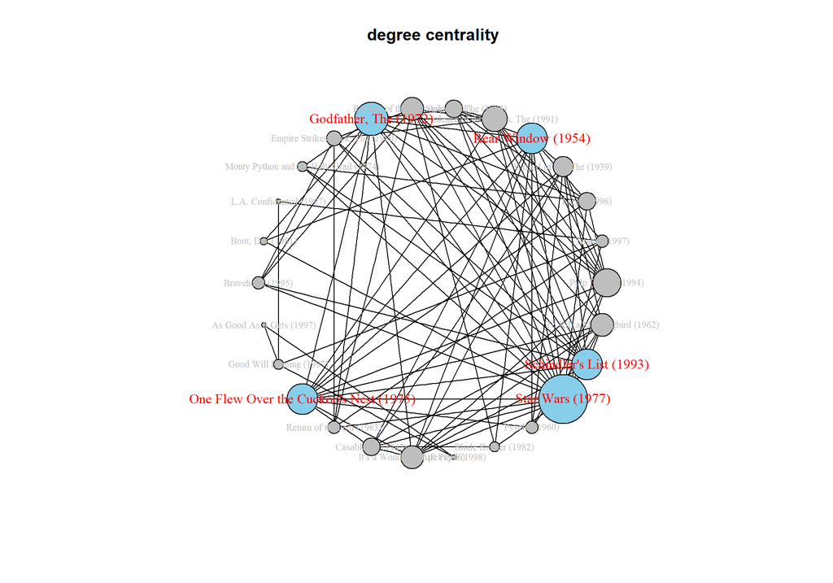

```r
## compute node closeness centrality
deg = degree(g2)
top = order(deg, decreasing = T)[1:5]

centralPlot(g2,deg,top,1.5)
title("degree centrality")
```

Whether exluding 4 independent nodes does not influence the structure.

### Closeness centrality

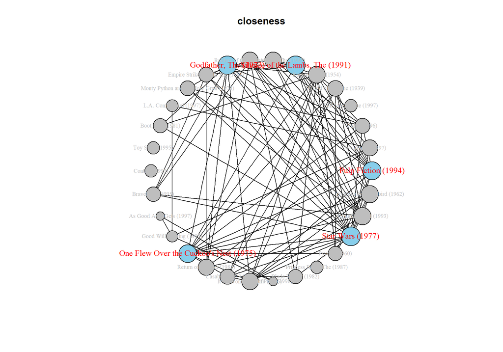

```r
## compute node closeness centrality
clo = closeness(g1)
top = order(clo, decreasing = T)[1:5]

centralPlot(g1,clo,top,1e+04)
title("closeness")
```

### Betweenness centrality

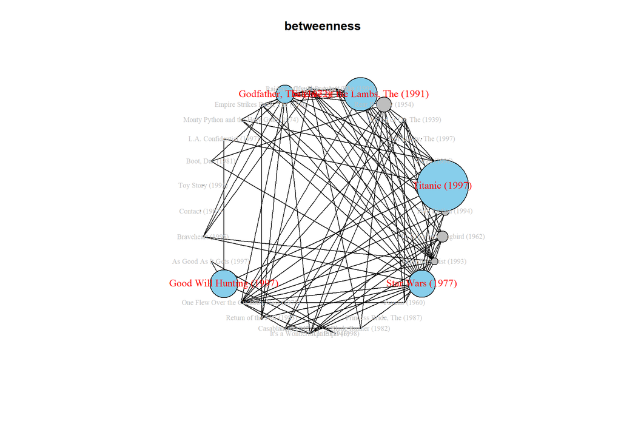

```r
## compute node closeness centrality
bet = betweenness(g1)
top = order(bet, decreasing = T)[1:5]

centralPlot(g1,bet,top,0.5)
title("betweenness")
```

### PageRank

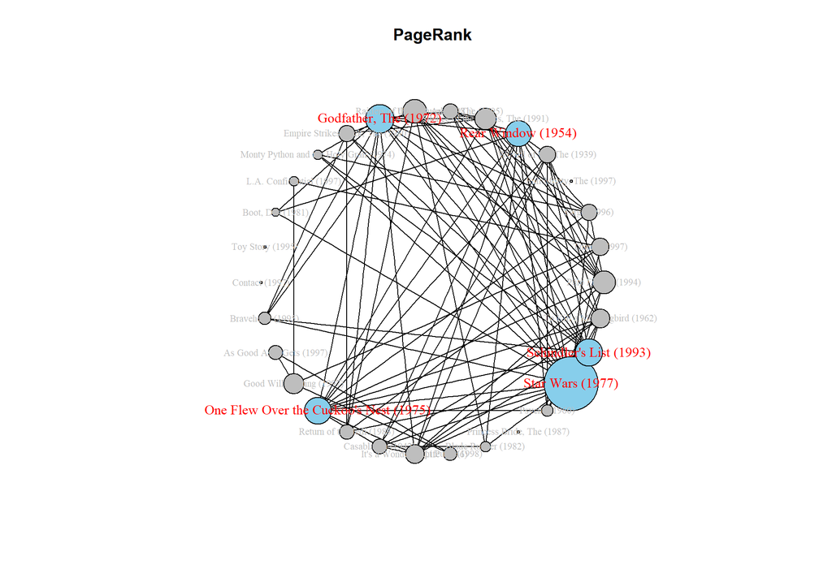

```r
## compute node closeness centrality
pg = page.rank(g1)$vector
top = order(pg, decreasing = T)[1:5]

centralPlot(g1,pg,top,300)
title("PageRank")
```

## 2.4 Observation based on these plots

### 2.4.1 Independent nodes do not influence modularity community.

Closeness highlights nodes has shortest average path to other nodes. In this case, most nodes have similar weight(reflect in dot size) in terms of closeness.

Betweenness shows nodes play a important role in brigding other nodes. Bridges to different part have highest weight.

```r
rm(list = ls())
```

# Task 3: Recommender system based on the book rating data

## Prepare data

load the BX-Book-Ratings.csv & BX-Books.csv data.

```r
book.rating = read.csv("BX-Book-Ratings.csv",sep=";", head=T)
books = read.csv("BX-Books.csv",sep=";", head=T)
#colnames(dataset) = c("userID","itemID", "rating", "timestamp")
head(book.rating)
```

```
##   User.ID       ISBN Book.Rating
## 1  276725 034545104X           0
## 2  276726 0155061224           5
## 3  276727 0446520802           0
## 4  276729 052165615X           3
## 5  276729 0521795028           6
## 6  276733 2080674722           0
```

```r
head(books)
```

```
##         ISBN
## 1 0195153448
## 2 0002005018
## 3 0060973129
## 4 0374157065
## 5 0393045218
## 6 0399135782
##                                                                                           Book.Title
## 1                                                                                Classical Mythology
## 2                                                                                       Clara Callan
## 3                                                                               Decision in Normandy
## 4 Flu: The Story of the Great Influenza Pandemic of 1918 and the Search for the Virus That Caused It
## 5                                                                             The Mummies of Urumchi
## 6                                                                             The Kitchen God's Wife
##            Book.Author Year.Of.Publication                  Publisher
```

[output cut: 27 more lines]

```r
books = books[,c(1,4)]
dim(book.rating)
```

```
## [1] 493813      3
```

```r
dim(books)
```

```
## [1] 115253      2
```

Extract books published from 1998 to present.

```r
## published after 1988
colnames(books)=c("ISBN","PublishYear")
books$PublishYear = as.character(books$PublishYear)
books$PublishYear = as.numeric(books$PublishYear)
books2 = books[books$PublishYear >= 1998,]
dim(books2)
```

```
## [1] 47876     2
```

```r
rm(books)
```

Create a book rating matrix from these books, and in this matrix, only consider books that were rated by at least 10 users, and users that rated at least 10 books.

```r
library(Matrix)
legalISBN = unique(books2$ISBN)
book.rating = subset(book.rating, ISBN %in% legalISBN)
# rating = data.frame(from = book.rating$User.ID, to = book.rating$ISBN,
#                     weight = book.rating$Book.Rating)
g = graph.data.frame(book.rating)
mat = get.adjacency(g)
mat.w = get.adjacency(g, attr = "Book.Rating")
user.idx = which(rowSums(mat) >= 10)
book.idx = which(colSums(mat) >= 10)

rmat = mat.w[user.idx, book.idx]
dim(rmat)
```

```
## [1] 1596 1425
```

## 3.1 Run and test a recommender system built with different recommendation methods

```r
suppressMessages(library(recommenderlab))
m = as.matrix(rmat)
m = as(m, "realRatingMatrix")
dim(m)
```

```
## [1] 1596 1425
```

```r
e = evaluationScheme(m, method = "cross", given=10,k = 4, goodRating = 6)
r1 = Recommender(getData(e, "train"), "RANDOM")
r2 = Recommender(getData(e, "train"), "POPULAR")
r3 = Recommender(getData(e, "train"), "UBCF")
r4 = Recommender(getData(e, "train"), "IBCF")
p1 = predict(r1, getData(e, "known"), type = "ratings")
p2 = predict(r2, getData(e, "known"), type = "ratings")
p3 = predict(r3, getData(e, "known"), type = "ratings")
p4 = predict(r4, getData(e, "known"), type = "ratings")
error = cbind(calcPredictionAccuracy(p1, getData(e, "unknown")),
              calcPredictionAccuracy(p2, getData(e, "unknown")),
              calcPredictionAccuracy(p3, getData(e, "unknown")),
              calcPredictionAccuracy(p4, getData(e, "unknown")))
colnames(error) = c("RANDOM","POPULAR","UBCF", "IBCF")
error
```

```
##         RANDOM   POPULAR       UBCF      IBCF
## RMSE 0.9675170 0.5330052 0.53459951 1.8934495
## MSE  0.9360891 0.2840945 0.28579664 3.5851510
## MAE  0.4707347 0.0882843 0.06428008 0.4486664
```

## 3.2 Observation

Item-based collaborative filtering(IBCF) got the worst performance, even worse than RANDOM methodï¼suggesting it changed a lot when doing cross-validation sampling.

POPULAR method and User-based collaborative filtering get better results. User-based similarity is more dynamic, therefore recomputing user neighbourhood can lead to poor predictions. But here, UBCF seems survive from cross-validation.